# calc_bird_age

```python
from IPython.display import Image, display
```

This is my example Python notebook.

I am going to calculate the human equivalent age for birds today

```python
bird_age = 8
human_age = bird_age * 5

print(f"A parrot who is age {bird_age} is actually {human_age} in human years")
```

```
A parrot who is age 8 is actually 40 in human years
```

# Foundational Understanding: Expressions & Variables

With Python, we processes values and produces results.  
We typically assign values to variables. (e.g. bird_age = 8) We manipulate variables with operators. (e.g., human_age = bird_age * 5)

Python programs evaluate expressions based upon input values

# Reusability and Organization

In Python, programmers use and/or write functions to manage the information or the task better.

Instead of rewriting calculations each time, we define functions.

Functions make code reusable and easy to manage/maintain. We "def" functions - example:

```python
def bird_to_human_years(bird_age):
    return bird_age * 5

print(f"Your bird's age in human years is: {bird_to_human_years(8)}")
```

```
Your bird's age in human years is: 40
```

What if you have multiple birds?

We need a sequence.

```python
ages = range(0,11)

for age in ages:
    print(f"If your bird's age is {age}, in human years your bird is {bird_to_human_years(age)}")
```

```
If your bird's age is 0, in human years your bird is 0
If your bird's age is 1, in human years your bird is 5
If your bird's age is 2, in human years your bird is 10
If your bird's age is 3, in human years your bird is 15
If your bird's age is 4, in human years your bird is 20
If your bird's age is 5, in human years your bird is 25
If your bird's age is 6, in human years your bird is 30
If your bird's age is 7, in human years your bird is 35
If your bird's age is 8, in human years your bird is 40
If your bird's age is 9, in human years your bird is 45
If your bird's age is 10, in human years your bird is 50
```

## Input Validation (Handling Incorrect Inputs)

- The idea - the functions you write should only process valid inputs.
- What happens if the data contains -3? The result wouldn’t make sense.
- The fix: use conditional statements (if, elif, else).

We should be or become "defensive" programmers and defend against bad input.

```python
def bird_to_human_years(bird_age):
    if bird_age <= 0:
        return "Age must be a positive number."
    return bird_age * 5

new_ages = [-3, 1, 2, 7]
for age in new_ages:
    print(bird_to_human_years(age))
```

```
Age must be a positive number.
5
10
35
```

# Check for understanding

- Python processes code sequentially
- Python execute one instruction at a time.

Example:

The bird_to_human_years function is called with bird_age = -3. The if statement checks bird_age <= 0. It is true, returns a warning.

The for allows Python to iterate (repeat) and process the next value. The function computes 1 * 5 = 5 and returns the result. Python repeats (iterates) until there are no more elements left in the sequence. It is passing each new value to the function and returning either a message or a computed value.

If the code is clear, you should be able to trace execution logically, anticipating what happens at each step.

# Modification

Suppose you wish to process a value like 2.5 years? What could you do? Could we/should enforce rounding?

```python
# let's test it first

new_ages = [-3, 1, 2.5, 7]
for age in new_ages:
    print(bird_to_human_years(age))
```

```
Age must be a positive number.
5
12.5
35
```

Suppose we need a nice message printed with the number? What can you do? At what point would you insert the message?

```python
# let's modify the message
new_ages = [-3, 1, 2.5, 7]
for age in new_ages:
    print(f"Your bird is {bird_to_human_years(age)} in human years")
```

```
Your bird is Age must be a positive number. in human years
Your bird is 5 in human years
Your bird is 12.5 in human years
Your bird is 35 in human years
```

Not so good, we didn't think it through well enough. Try again.

```python
# another try

new_ages = [-3, 1, 2.5, 7]
for age in new_ages:
    if age <= 0:
        print(bird_to_human_years(age))
    else:
        print(f"Your bird is {bird_to_human_years(age)} in human years")
```

```
Age must be a positive number.
Your bird is 5 in human years
Your bird is 12.5 in human years
Your bird is 35 in human years
```

Suppose you wanted to allow users to input values.

```python
def bird_to_human_years(bird_age):
    if bird_age <= 0:
        return "Age must be a positive number."
    return f"Your bird is {bird_age * 5} in human years"

bird_age = float(input("What the bird's age? "))
print(bird_to_human_years(bird_age))
```

```
Your bird is 30.0 in human years
```

But this is a little awkward if we want it interactive and shareable, so let's move it to a script.

We will call it bird_age.py

We will need to open it as a separate file.

Save it and maybe do a couple of things.

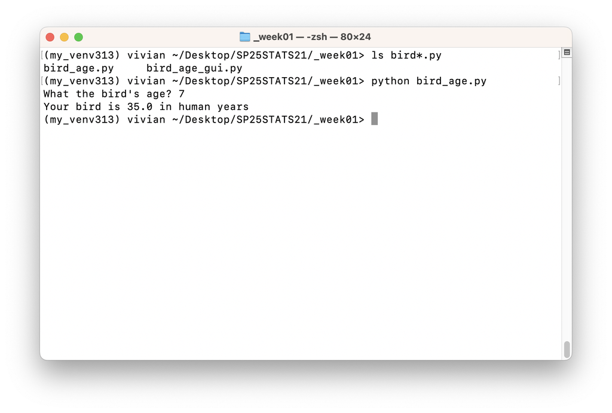

```python
# Displaying a local image
image_path = "_images/bird_age.png"  # Replace with your actual path
display(Image(filename=image_path))
```

# Additional Tasks, Challenges

1. Allow multiple kinds of animals (e.g., dog, cat)
2. Outline what you will need (e.g., need to find out what kind of pet, need to find formulas for translating their age, need to write separate functions)